# Task_3

Galikeeva

19 04 2020

1. Прочитать данные .

```r
Stocs = read.csv('Task_3_var_6.csv')
head(Stocs)
```

```
##     Stock1   Stock2   Stock3   Stock4   Stock5   Stock6   Stock7   Stock8
## 1 811.2035 531.5582 593.5517 852.3701 486.3881 830.9105 118.0132 121.7804
## 2 813.8040 511.7111 596.3550 856.7977 498.8225 827.8809 120.0797 124.5289
## 3 826.0100 498.2445 593.2464 858.9998 501.4497 819.8357 115.3478 126.5359
## 4 838.3222 489.9219 586.6392 845.5600 441.2111 802.7591 126.5794 124.3936
## 5 848.1026 510.1314 605.2410 856.4204 495.8228 813.4923 128.9412 124.4428
## 6 799.9778 503.7555 597.0483 842.8717 533.3841 808.6028 121.5086 121.7310
##       indx
## 1 543.2220
## 2 543.7475
## 3 542.4587
## 4 531.9233
## 5 547.8243
## 6 541.1100
```

```r
(ncol <- dim(Stocs)[2])
```

```
## [1] 9
```

```r
(nrow <- dim(Stocs)[1])
```

```
## [1] 200
```

```r
por <- 0
K = 1000000
b <- K / (ncol * Stocs[1,])
for (i in 1:nrow){
  por[i] <- sum (b * Stocs[i,])
}
Stocs <-cbind (Stocs, por)
```

2. Перейти к доходностям по формуле : $r_t(i)=S_t(i)/S_{t-1}(i)−1,i=1,...,N;t=2,...,T$

```r
rates <- Stocs[2:nrow,] / Stocs [1:(nrow-1),] - 1
head(rates)
```

```
##         Stock1      Stock2       Stock3       Stock4       Stock5       Stock6
## 2  0.003205806 -0.03733759  0.004722983  0.005194388  0.025564740 -0.003646169
## 3  0.014998597 -0.02631690 -0.005212737  0.002570181  0.005266788 -0.009717744
## 4  0.014905663 -0.01670379 -0.011137299 -0.015645860 -0.120128851 -0.020829308
## 5  0.011666658  0.04125050  0.031709085  0.012843964  0.123776864  0.013370386
## 6 -0.056744122 -0.01249852 -0.013536153 -0.015820159  0.075755556 -0.006010465
## 7  0.018539497 -0.01266740  0.005621204 -0.019564154 -0.016836396  0.005213262
##        Stock7        Stock8          indx          por
## 2  0.01751044  0.0225692742  0.0009673844  0.004305695
## 3 -0.03940620  0.0161161142 -0.0023701604 -0.004780654
## 4  0.09737138 -0.0169303293 -0.0194215703 -0.012627629
## 5  0.01865908  0.0003961414  0.0298934385  0.030291166
## 6 -0.05764316 -0.0217922033 -0.0122563617 -0.013909661
## 7  0.06270084  0.0019627755 -0.0003675803  0.005025675
```

3. Bычислить изменение стоимости каждой акции за один день
   $$ΔS_t(i)=S_t(i)r_t(i)$$
   и портфеля в целом за день
   $$ΔП_t=Σ_{i=1}^Nβ_iΔS_t(i))$$

```r
del_s <- Stocs[1:(nrow - 1),1:ncol] * rates[,1:ncol]
head(del_s)
```

```
##       Stock1     Stock2    Stock3     Stock4     Stock5     Stock6    Stock7
## 1   2.600561 -19.847105  2.803335   4.427541  12.434385  -3.029640  2.066463
## 2  12.205919 -13.466649 -3.108642   2.202125   2.627192  -8.045134 -4.731883
## 3  12.312226  -8.322571 -6.607162 -13.439791 -60.238571 -17.076611 11.231575
## 4   9.780418  20.209524 18.601792  10.860343  54.611725  10.733199  2.361854
## 5 -48.124838  -6.375887 -8.192635 -13.548706  37.561333  -4.889467 -7.432580
## 6  14.831185  -6.381272  3.356131 -16.490071  -8.980267   4.215458  7.618695
##        Stock8        indx
## 1  2.74849622   0.5255045
## 2  2.00692262  -1.2887687
## 3 -2.14229382 -10.5353999
## 4  0.04927744  15.9010166
## 5 -2.71188380  -6.7143330
## 6  0.23893055  -0.1989013
```

```r
del_p <- 0
for (i in 1:(nrow-1)) {
  del_p[i] <- sum(b * del_s[i,])
}
head(del_p)
```

```
## [1]   4305.695  -4801.238 -12621.371  29893.839 -14143.022   5038.912
```

4. Проверить нормальность распределения изменения стоимости портфеля $ΔП_t$. Используем гистограмму и нормальный q-q plot

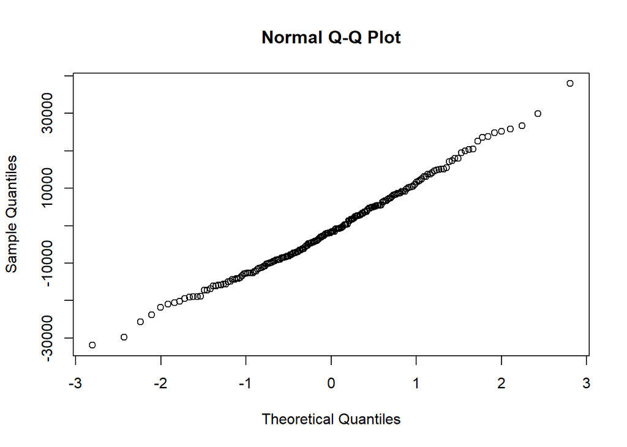

```r
qqnorm(del_p)
```

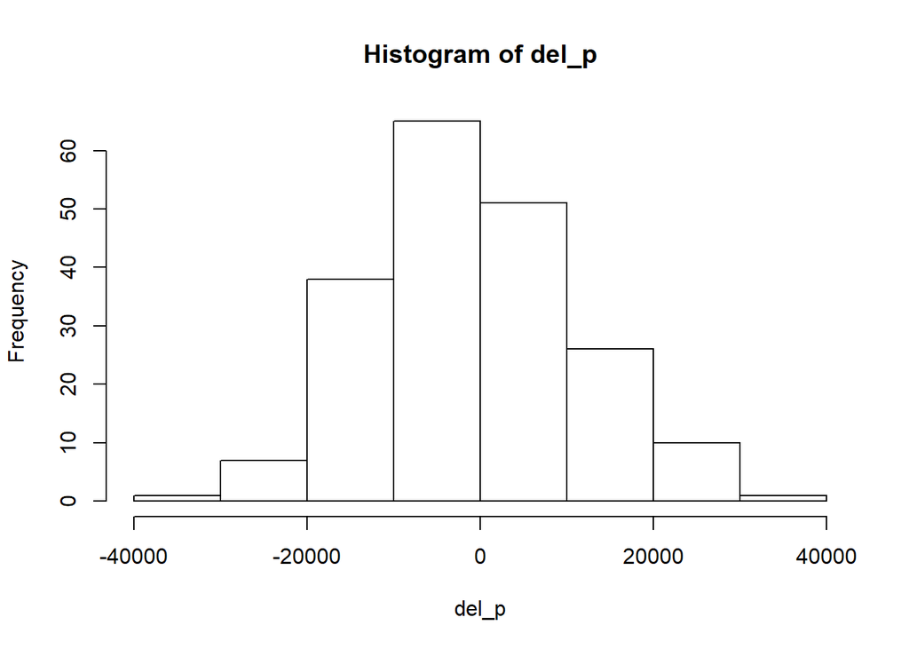

```r
hist(del_p)
```

```r
vol_ds <- 0
mean_ds <- 0
Var <- cbind (del_s, del_p)
al = 0.95
Var_del <- Var[1,]
for(i in 1:(ncol + 1))
  mean_ds[i] <- mean(Var[,i])
  vol_ds[i] <- sd(Var[,i])
  Var_del[i] = qnorm(1-al,mean=mean(Var[,i]),sd=sd(Var[,i]))
Var_del
```

```
##     Stock1   Stock2   Stock3   Stock4   Stock5   Stock6   Stock7   Stock8
## 1 2.600561 -19.8471 2.803335 4.427541 12.43438 -3.02964 2.066463 2.748496
##        indx     del_p
## 1 0.5255045 -20945.85
```

6. Вычислить нормальный (геометрическая модель) VAR уровня 95% для каждого актива и всего портфеля в целом.
   $$VaR=S(1-e^{-\mu _{i}T+z_{\alpha }\sigma _{i}{\sqrt {T}}})$$

```r
s_1 <- 0
mu <- 0
sig <- 0
Var_g <- 0
for (i in 1:10) {
  s_1[i] <- mean(Stocs[,i])
  mu[i] <- mean(rates[,i])
  sig[i] <- sd(rates[,i])
  Var_g[i] <- s_1[i] * (1 - exp(-mu[i] * nrow + qnorm (al, mean = mu[i], sd = sig[i]) * sig[i] * sqrt(nrow)))
}
Var_g
```

```
##  [1]    -350.26226    -157.41444     -93.92045    -190.68769     256.13607
##  [6]    -421.91913      25.17623     -51.82467    -138.37308 -203088.73898
```

```r
Var_h <-0
for (i in 1 : ncol){
  Var_h[i] <- (-1 * quantile(del_s[,i], cbind(1 - al), al))
}
Var_h
```

```
## [1] 28.582578 20.757726 10.711534 32.108750 55.856190 29.077626  8.547035
## [8]  4.384565 10.081234
```

```r
(-1 * quantile(del_p, cbind(1 - al), al))
```

```
##      5%
## 19010.5
```

8. Вычислить исторический Shortfall (арифметическая модель) уровня 95% для каждого актива и всего портфеля в целом.

```r
library(PerformanceAnalytics)
```

```r
for(i in 1:ncol){
  ES(del_s[,i], p=al, method="historical")
}
```

[output not shown]

[output not shown]

[output not shown]

[output not shown]

[output not shown]

[output not shown]

[output not shown]

[output not shown]

[output not shown]

```r
ES(del_p, p=al, method="historical")
```

```
## ES calculation produces unreliable result (risk over 100%) for column: 1 : 23326.4233125085
```

```
##    [,1]
## ES   -1
```

9. Вычислить коэффициент $β_i$ и $α_i$ для каждого акции $i=1,...N−1$. Используем определения.
   $$\beta_{i}=\frac{cov(\rho_{i},\rho)}{D[\rho]}$$
   $$\alpha_i=E(R_{i})-R_{f}-\beta _{{i}}(E(R_{m})-R_{f})$$

```r
(beta <- cov (rates[, 1:(ncol - 1)], rates[, ncol]) / var(rates[, ncol]))
```

```
##              [,1]
## Stock1 1.02532712
## Stock2 0.70164752
## Stock3 0.91046461
## Stock4 0.68447820
## Stock5 2.22191741
## Stock6 0.65351132
## Stock7 1.04707745
## Stock8 0.03929327
```

```r
r <- 0.07
(alpha_manual <- colMeans(rates[, 1:(ncol - 1)])- r- beta*(colMeans (rates[, 1:ncol - 1]) - r))
```

```
##                [,1]
## Stock1  0.001826146
## Stock2 -0.021278794
## Stock3 -0.006329175
## Stock4 -0.022429241
## Stock5  0.082643082
## Stock6 -0.024953491
## Stock7  0.003242724
## Stock8 -0.068960797
```

10. Вычислить коэффициент Шарпа для данного портфеля. Через определение
    $$S=\frac{E[r_{p}-r_f]}{\sqrt{D[r_{p}-r_f]}}$$

```r
(Sha <- mean (rates[, ncol + 1] - r) / sd (rates[, ncol + 1] - r))
```

```
## [1] -5.981189
```

11. Вычислить нормальный Shortfall уровня 95% для акций и всего портфеля в целом кроме числовых вычислений привести явный вид формулы, в которой через $N(x)$ обозначена формула для функции распределения стандартного нормального распределения.

```r
sh_f <- 0
del_v <- 0
for (i in 1:ncol) {
  d <- diff (Stocs[,i])
  m <- mean (d)
  sd <- sd (d)
  del_v[i] <- qnorm (1 - al, mean = m, sd = sd)
  sh_f[i] <- ((-1 * sd * exp (-(del_v[i] - m) * (del_v[i] - m) / (2 * sd * sd)))/ sqrt (2 * pi) + m * pnorm ((del_v[i] - m) / sd)) / (1 - al)
}
sh_f
```

```
## [1] -39.176307 -26.701217 -14.439727 -38.905374 -58.503833 -34.310232 -12.283720
## [8]  -5.763239 -12.397853
```

Формула: $Shortfall_α(X) = (∫^{Var_α}_{−∞}xf(x)dx)/(∫^{Var_α}_{−∞}f(x)dx) = (∫^{Var_α}_{−∞}xe^{−(x−μ)/σ^2}dx) / (1 - α) = (−σe^{−(Var_α−μ)/σ^2})/2√π+μN((Var_α−μ)/σ) / (1 - α)$